# Examen Simulación

Primer Bimestre

14 de julio de 2020

**Apellidos**: Gavilanes Guerrero

**Nombre**: Viviana

# Teoría

## Inversión

Describir un algoritmo basado en el método de inversión que permita generar observaciones de una variable aleatoria con distribución exponencial “inflada con ceros” (*zero inflated*), con función de distribución:
$$F(x)=\left\{
\begin{array}{ll}
0 & \text{si } x < 0,\\
\pi + \left( 1-\pi \right)\left(1-e^{-\lambda x}\right) & \text{si } x \ge 0,
\end{array}
\right.$$

siendo $\pi = P(X=0) \ge 0$.

#### *Solución:*

Para describir el algoritmo basado en el método de inversión debemos encontrar $F^{-1}$, la inversa de $F$.

Analicemos:

- Si $x<0$, la función inversa toma el valor de $0$.
- Si $x \geq 0$:

Tenemos que
$$\pi + (1 - \pi) (1-e^{-\lambda x}) = u,$$
de donde, al despejar $e^{-\lambda x}$, obtenemos que
$$e^{-\lambda x} = \frac{1-u}{1-\pi},$$
de esta expresión, es claro que $\pi \neq 1$. Tomando el logaritmo natural en ambos lados de la última igualdas y despejando $x$ se tiene que
$$x = -\frac{1}{\lambda} \text{ln} \left(\frac{1-u}{1-\pi} \right).$$
Recordando la relación entre una función y su inversa, tenemos que:
$$F^{-1}(x)= x = G(u) = -\frac{1}{\lambda} \text{ln} \left(\frac{1-u}{1-\pi} \right).$$
Ahora, analicemos en para qué valores de $u$ está bien definida. Tenemos dos condiciones:

- $x \geq 0$ lo que implica que $-\frac{1}{\lambda} \text{ln} \left(\frac{1-u}{1-\pi} \right) \geq 0$, de donde:

$$\begin{align*}
-\frac{1}{\lambda} \text{ln} \left(\frac{1-u}{1-\pi} \right) &\geq 0 \\
\text{ln} \left(\frac{1-u}{1-\pi} \right) &\leq 0 \\
e^{ \text{ln} \left(\frac{1-u}{1-\pi} \right)} & \leq e^{0}\\
\frac{1-u}{1-\pi} &\leq 1\\
1-u &\leq 1 - \pi.
\end{align*}$$
Por lo tanto,
$$\begin{equation}\tag{1}
u \geq \pi.
\end{equation}$$

- Como el logaritmo natural está definido en argumentos estrictamente mayores que 0, también debe cumplirse que
  $$\frac{1-u}{1-\pi} > 0,$$
  de donde

$$\begin{equation}\tag{2}
u < 1.
\end{equation}$$

En resumen, de (1) y (2), tenemos que
$$\pi \leq u < 1.$$

Así, definimos la inversa de $F$ como sigue:

$$G(u)=\left\{
\begin{array}{ll}
-\frac{1}{\lambda} \text{ln}\left( \frac{1-u}{1-\pi}\right) & \text{si } \pi \leq u < 1,\\
0 & \text{en otro caso.}
\end{array}
\right.$$

Formulamos el algoritmo de inversión para este caso.

#### **Algoritmo de Inversión**

1. Definir el valor de $\lambda$ y $\pi$.
2. Generar $U \sim \mathcal{U}(0,1).$
3. Si $\pi \leq U < 1$, entonces devolver $X = -\frac{1}{\lambda} \text{ln}\left( \frac{1-U}{1-\pi}\right)$

Ejemplo práctico (no se pidió pero me pareció interesante desarrollarlo). Tomaré el caso particular cuando $\pi = 0$ en donde es evidente que $f(x)$ coincide con una exponencial de parámetro $\lambda$ y tomaré $\lambda = 1$.

Defino las funciones necesarias con base en el **Algoritmo de Inversión**

```r
lambda<<-1
pi_X<<-0


set.seed(54321)

F_x <- function(x){
         return(pi_X+((1-pi_X)*(1-exp(-lambda*x))))
}

F_x_2 <- function(lambda,pi_X){
  if(x >= 0)
    return(pi_X+((1-pi_X)*(1-exp(-lambda*x))))
}


F_inv <- function(lambda =1,pi_X){
  # Simulación
  U <- runif(1,min=0,max=1)
  if(pi_X <= U && U < 1 ){
    return(-1/lambda * log((1-U)/(1-pi_X)))
  }
  else(return(0))
}


F_inv_n <- function(n=1000){
  # muestra de n valores de la distribución cero inflated
  x <- numeric(n)
  for (i in 1:n) x[i] <- F_inv(lambda,pi_X)
  return(x)
}
```

Generamos la muestra

```r
system.time(x<- F_inv_n(1000))
```

```
##    user  system elapsed
##    0.06    0.00    0.06
```

Graficamos para comparar la simulación con la parte teórica.

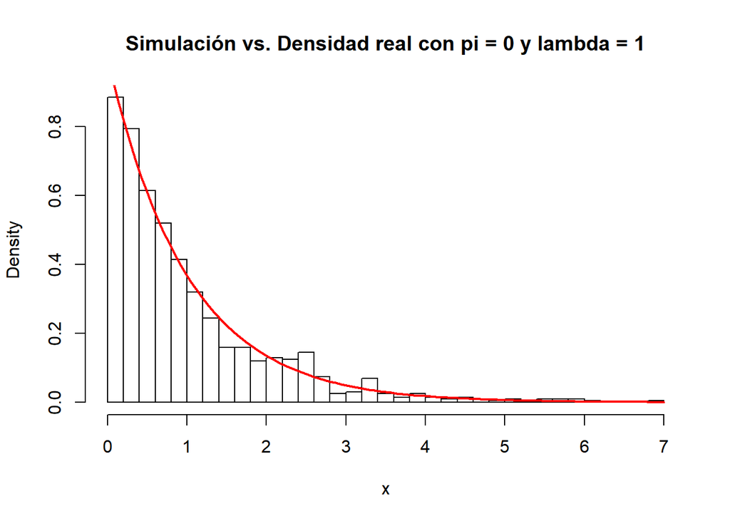

```r
hist(x,breaks="FD", freq=FALSE,xlim = c(0,7), main="Simulación vs. Densidad real con pi = 0 y lambda = 1")
curve(dexp(x, lambda), lwd = 2, add = TRUE, col='red')
```

Vemos que los datos simulados se ajustan a la distribución exponencial de parámetro $\lambda = 1$.

## Aceptación-rechazo

Dar un algoritmo basado en el método de aceptación-rechazo (considerando como densidad auxiliar una uniforme) que permita generar observaciones de una variable aleatoria bidimensional $\left( X,Y\right)$ con función de densidad:
$$f(x,y)=\left\{
\begin{array}{cl}
\frac{1}{8} \left( x + y \right) & \text{si } 0 \le x \le 2 , 0 \le y \le 2\\
0 & \text{en otro caso}
\end{array}
\right.$$

¿Cuál sería el valor esperado de generaciones de la densidad auxiliar?

#### *Solución*

Definimos la densidad uniforme $g(x,y)$ sobre $[0,2]\times[0,2]$, dado que el área sobre este cuadrado es igual a $4$ y al integrar $g$ para ser densidad el valor debe ser igual a $1$ entonces tenemos que

$$g(x,y)=\left\{
\begin{array}{cl}
\frac{1}{4} & \text{si } 0 \le x \le 2 , 0 \le y \le 2\\
0 & \text{en otro caso}
\end{array}
\right.$$

Como $f(x,y) \leq M = f(2,2) = \frac{1}{2}$, tomando
$$c = \frac{M}{g(x,y)}= \frac{\frac{1}{2}}{\frac{1
}{4}} = 2.$$
Tenemos que
$$f(x,y) \leq c \, g(x,y) = M.$$

Recordando que
$$E(N) = c,$$
concluimos que el valor esperado de generaciones de la densidad auxiliar es
$$E(N) = 2.$$

Otra forma de calcular $c$:

$$c= \max_{\{(x,y) : g(x,y)>0\}} \frac{f(x,y)}{g(x,y)}$$

Evidentemente el valor máximo de $f(x,y)$ se alcanza en $(x,y)=(2,2)$. Por lo tanto
$$c = \frac{f(2,2)}{\frac{1}{4}} = 2$$

Formulamos el algoritmo del método de aceptación-rechazo para este caso.

#### **Algoritmo de Aceptación-rechazo**

1. Generar $U \sim \mathcal{U}(0,1)$.
2. Generar $X, Y \sim \mathcal{U}(0,2).$
3. Si $\frac{1}{2} \cdot U \cdot g(X,Y) \leq f(X,Y)$, entonces devolver $\text{Par}=(X,Y)$.
4. En caso contrario volver al paso 1.

Ejemplo práctico (no se pidió pero me pareció interesante desarrollarlo). Primero definimos las funciones necesarias:

```r
# Implementamos la función original:

f_xy<-function(x,y){
  if (x<=2 && x>=0  && y<=2 && y>=0  )
  {
    return((x+y)/8)
  }
  else {return(0)}
}

# Definimos la función de densidad auxiliar uniforme


g_xy <-function(x,y){
  if (x<=2 && x>=0  && y<=2 && y>=0 ){
    return(1/4)
  }
  else {return(0)}
}



rx_ex <- function(){
  #Simulación por aceptación-rechazo
  M <- 1/2
  ngen<<-0
  while(TRUE){
    U <- runif(1,1)
    X<-runif(1,0,2)
    Y<-runif(1,0,2)
    par<-c(X,Y)
    ngen <<- ngen+1 # Comentar esta línea para uso normal
    if(M*U*g_xy(X,Y)/f_xy(X,Y)<= 1)
    {
      return(par)
    }
  }
}

rx_exn<-function(nsim=1000){
  x<-numeric(2*nsim)
  x<-matrix(x,nrow=nsim)
  #ngen<<-0
  for(i in 1:nsim) {
    x[i,1]<-rx_ex()[1]
    x[i,2]<-rx_ex()[2]
   # ngen <<- ngen+1 # Comentar esta línea para uso normal
  }
  return(x)
}
```

Obtenemos la muestra:

```r
system.time(muestra2<- rx_exn(1000))
```

```
##    user  system elapsed
##    0.14    0.03    0.19
```

Graficamos el plot de puntos:

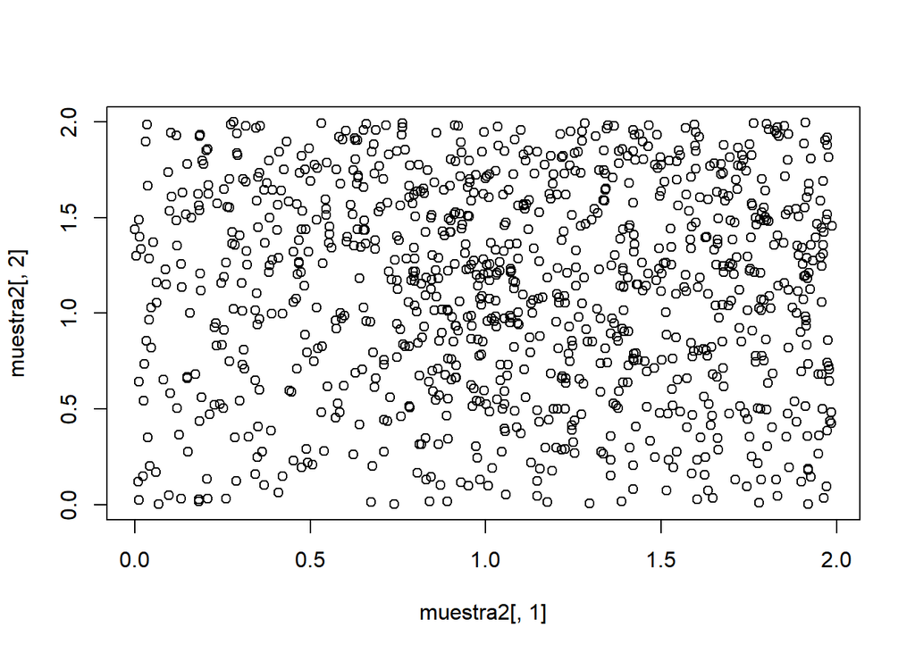

Graficamos en 3D la comparación simulada vs teórica:

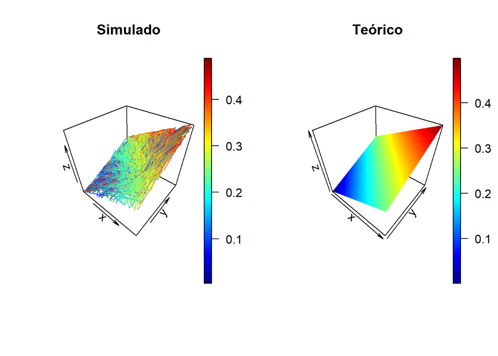

```
## El número de generaciones es igual a 2
```

# Práctica

Estamos interesados en una variable con función de densidad $Gamma(s,r)$:
$$f(x)=\frac{r^{s}}{\Gamma (s)}x^{s-1}e^{-rx}\text{ si }x\geq 0,$$
(siguiendo la notación de la función `dgamma(x, shape, rate)` de `R`). Escribir el código necesario para generar, por el método de aceptación-rechazo, una muestra de $n$ observaciones de una distribución $Gamma(3,3)$ empleando como densidad auxiliar una exponencial (`dexp(x, rate)`):
$$g(x)=\lambda e^{-\lambda x}\text{ si }x\geq 0.$$
(NOTA: Emplear la función $\Gamma (s)$ implementada en R: gamma(s) ).

#### *Solución*

Definimos las funciones adecuadas para aplicar el método de aceptación-rechazo:

```r
ngen<-0

f_x_gamma <-function(x,s,r){
  if(x>=0){
    # f(x) = xe^{-x} si x >= 0
    return((r^s/gamma(s))*x^(s-1)*exp(-r*x))
  }
}

g_x<- function(x,lambda){
  if(x>=0){
    return(lambda*exp(-lambda*x))
  }
}


rdexp_aux <- function(lambda = 1){
  # Inversa de la exponencial
  U <- runif(1)
  return(-log(1-U)/lambda)
}

rx_ex_gamma <- function(){
  #Simulación por aceptación-rechazo
  #f(x) = x e^{-x}, si x >= 0
  while(TRUE){
    U <- runif(1)
    #X <-lambda.opt1*exp(-lambda.opt1*x)
    X <- rdexp_aux(lambda.opt1)
    ngen <<- ngen+1 # Comentar esta línea para uso normal
    if(c.opt1*U*g_x(X,lambda.opt1)/f_x_gamma(X,r,s)<= 1) return(X)
  }
}

rx_exn<- function(n=1000) {
  # Simulación n valores f_x
  x <- numeric(n)
  ngen <<- 0 # Comentar esta línea para uso normal
  for(i in 1:n) x[i]<-rx_ex_gamma()
  return(x)
}
```

```r
# Valores teóricos:
c.opt1<-27/(2*exp(2))
lambda.opt1 <- 1
r<-3
s<-3

# Obtención de valores c y lambda óptimos aproximados
fopt <- function(lambda) {
  # Obtiene c fijado lambda
  optimize(f = function(x){f_x_gamma(x,r,s)/g_x(x,lambda)},
           maximum=TRUE, interval=c(0,2))$objective
}

# Encontar lambda que minimiza
res <- optimize(f=function(x){fopt(x)}, interval=c(0,2))
lambda.opt2 <- res$minimum
c.opt2 <- res$objective
```

Luego de realizar la simulación obtenemos que:

```
## El lambda óptimo es igual a  0.999986
```

```
## El c óptimo es igual a  1.827026
```

Comparamos el valor de $\lambda_{\text{opt}}$ y $c_{\text{opt}}$ con los valores de la simulación mediante el calculo del error:

```
## El error absoluto del lambda óptimo simulado con respecto al valor teórico es 1.400541e-05
```

```
## El error absoluto del c óptimo simulado con respecto al valor teórico es 1.456324e-11
```

**b) Generar una muestra de $1000$ observaciones de la distribución de interés tomando como semilla inicial los cuatro primeros dígidos de la cédula. Obtener el tiempo de CPU que tarde en generar la secuencia y calcular el número medio de generaciones de la distribución auxiliar.**

```r
nsim <- 10^4
set.seed(1726)
system.time(x<-rx_exn(nsim))
```

```
##    user  system elapsed
##    0.55    0.06    0.63
```

Obtenemos la información sobre las generaciones de la distribución auxiliar:

```
## No. de generaciones de la distribución auxiliar =  18536
```

```
## No. medio de generaciones de la distribución auxiliar =  1.8536
```

```
## Proporción de rechazos =  0.4605093
```

**c) Representar el histograma y compararlo con la densidad teórica.**

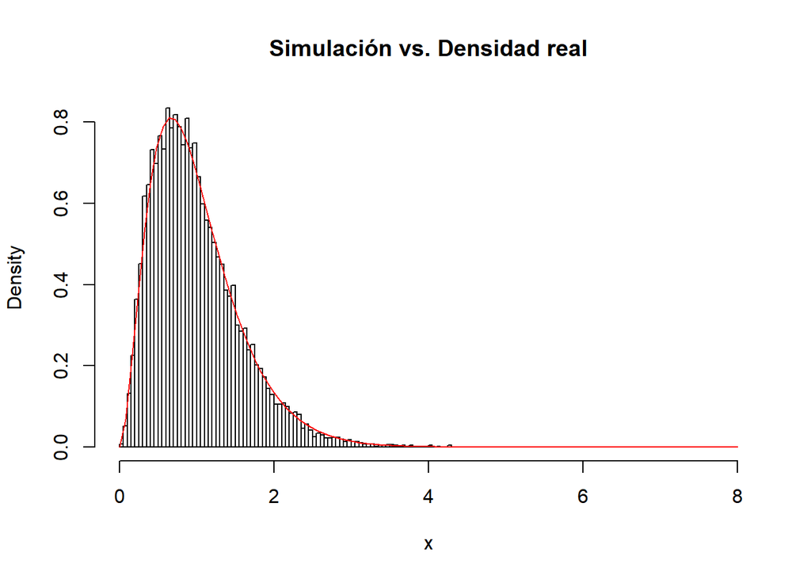

#### Conclusiones:

- Tanto para el valor del $\lambda_{\text{opt}}$ como para el del $c_{\text{opt}}$ vemos que el error es muy próximo a $0$. Por lo tanto, la aproximación es exitosa.
- El número de generaciones de la distribución auxiliar es igual a $18536$ y el número medio igual a $1.8536$. Por otro lado, el porcentaje de rechazo es aproximadamente el $46.05\%$.
- Al comparar el histograma con la densidad teórica tenemos que los datos simulados se ajustan exitosamente a la densidad teórica.